# Alec Jones Honours Thesis Code

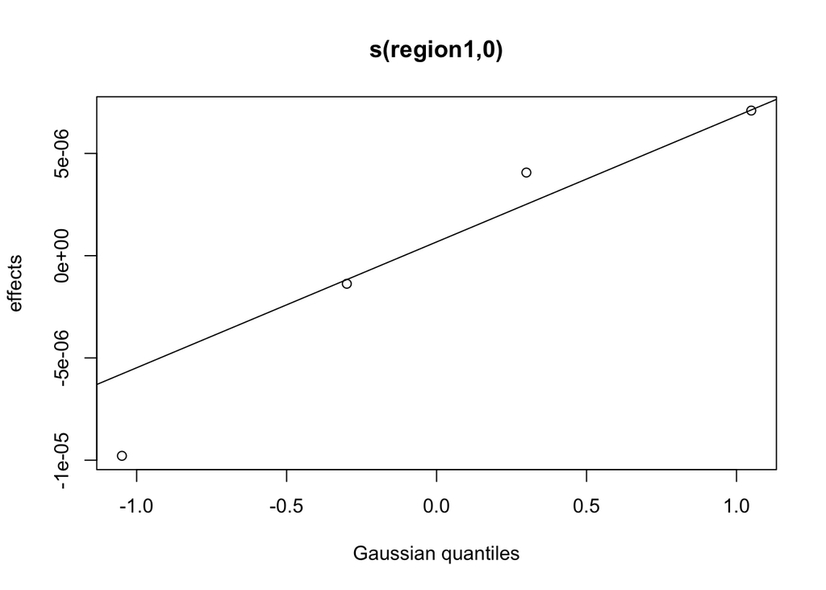

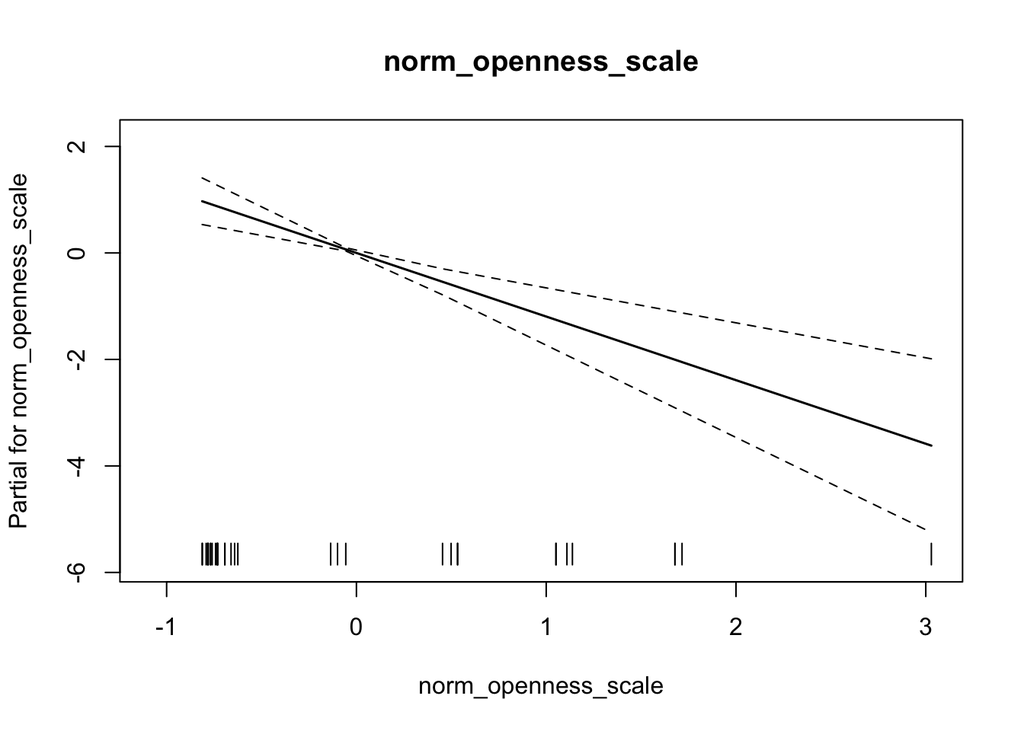

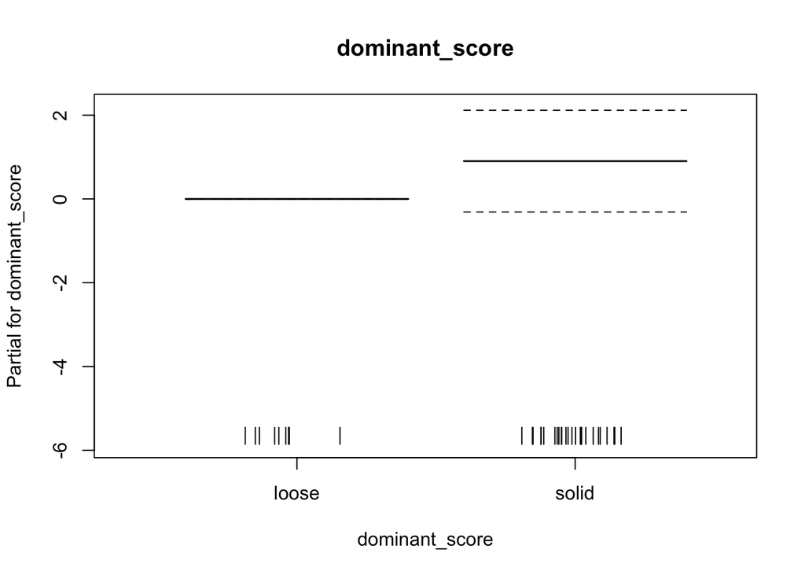

```
##
## Family: gaussian
## Link function: identity
##
## Formula:
## log(snail_dens + 0.01) ~ s(sst_scale) + norm_openness_scale +
##     dominant_score + s(region1, bs = "re")
##
## Parametric coefficients:
##                     Estimate Std. Error t value Pr(>|t|)
## (Intercept)          -1.6126     0.5178  -3.114 0.003870 **
## norm_openness_scale  -1.1945     0.2691  -4.439 0.000101 ***
## dominant_scoresolid   0.9029     0.6069   1.488 0.146597
## ---
## Signif. codes:  0 '***' 0.001 '**' 0.01 '*' 0.05 '.' 0.1 ' ' 1
##
## Approximate significance of smooth terms:
##                    edf Ref.df F p-value
## s(sst_scale) 2.382e-05      9 0   0.788
## s(region1)   4.209e-05      3 0   0.490
##
## R-sq.(adj) =  0.343   Deviance explained = 38.2%
## -REML = 62.975  Scale est. = 2.2703    n = 35
```

##### Testing the residuals for autocorrelation

```
##
##  Moran I test under randomisation
##
## data:  residuals_ecology_snail_mod_linear_re
## weights: lw
## n reduced by no-neighbour observations
##
## Moran I statistic standard deviate = 1.0933, p-value = 0.2743
## alternative hypothesis: two.sided
## sample estimates:
## Moran I statistic       Expectation          Variance
##        0.29408322       -0.05882353        0.10419886
```

```
##
##  Moran I test under randomisation
##
## data:  residuals_ecology_snail_mod_linear_re
## weights: lw_inverse
##
## Moran I statistic standard deviate = 1.9598, p-value = 0.05002
## alternative hypothesis: two.sided
## sample estimates:
## Moran I statistic       Expectation          Variance
##        0.30424465       -0.02941176        0.02898615
```

No autocorrelation for both methods when using a two sided test.

##### Testing the model for concurvity

```
## $worst
##                      para s(sst_scale) s(region1)
## para         1.000000e+00 4.176841e-24  1.0000000
## s(sst_scale) 4.162202e-24 1.000000e+00  0.9999999
## s(region1)   1.000000e+00 9.999999e-01  1.0000000
##
## $observed
##                      para s(sst_scale) s(region1)
## para         1.000000e+00 4.352482e-31  0.2791669
## s(sst_scale) 4.162202e-24 1.000000e+00  0.7078920
## s(region1)   1.000000e+00 2.070626e-01  1.0000000
##
## $estimate
##                      para s(sst_scale) s(region1)
## para         1.000000e+00 9.168891e-28  0.3926531
## s(sst_scale) 4.162202e-24 1.000000e+00  0.5771556
## s(region1)   1.000000e+00 6.222112e-01  1.0000000
```

```
##          para s(sst_scale) s(region1)
## worst       1    0.9999999  1.0000000
## observed    1    0.2751993  0.9887453
## estimate    1    0.6893833  0.9736525
```

Random effect of region is highly concurve.

#### Model 4: Ecology model on the snail counts with temperature, openness, and bottom type and fixed effect of region (linear openness)

```r
#We were also curious to look at region as a fixed effect so we tried a model
#with this included
ecology_snail_mod_linear_fe <- gam(log(snail_dens + 0.01) ~ s(sst_scale)+
                               norm_openness_scale +
                           dominant_score+
                                region1,
                             data = env_mod_data_hon,
                             family = gaussian(link = "identity"),
                             method = "REML",
                             select = TRUE)
```

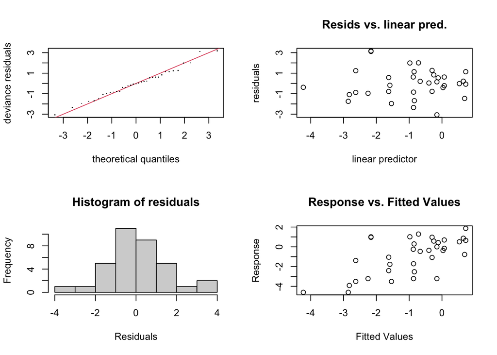

```
##
## Method: REML   Optimizer: outer newton
## full convergence after 8 iterations.
## Gradient range [-2.061831e-05,4.525727e-06]
## (score 59.87327 & scale 2.339865).
## Hessian positive definite, eigenvalue range [1.349218e-06,14.5].
## Model rank =  15 / 15
##
## Basis dimension (k) checking results. Low p-value (k-index<1) may
## indicate that k is too low, especially if edf is close to k'.
##
##                   k'     edf k-index p-value
## s(sst_scale) 9.0e+00 5.3e-05    0.96    0.34
```

```
##
##  Shapiro-Wilk normality test
##
## data:  ecology_snail_mod_linear_fe$residuals
## W = 0.98518, p-value = 0.9082
```

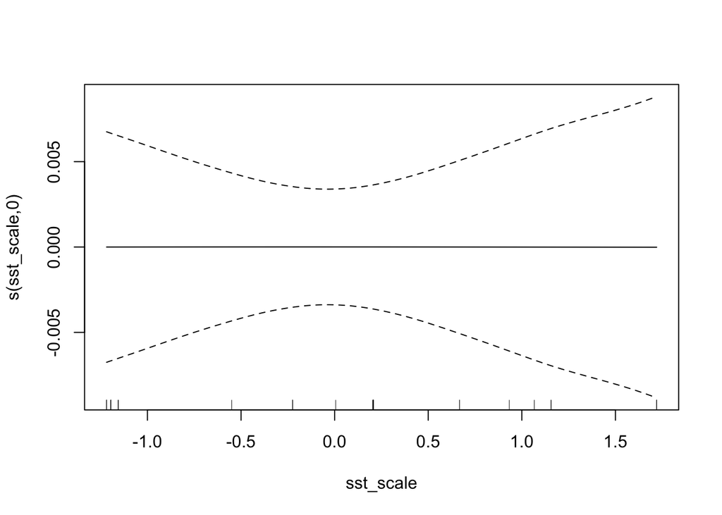

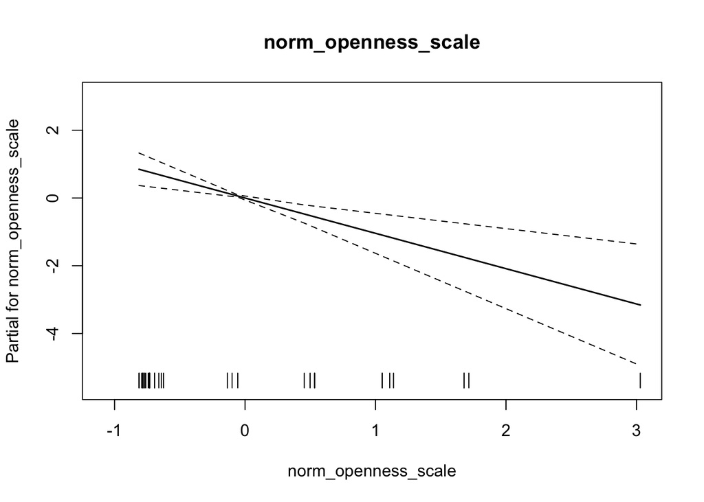

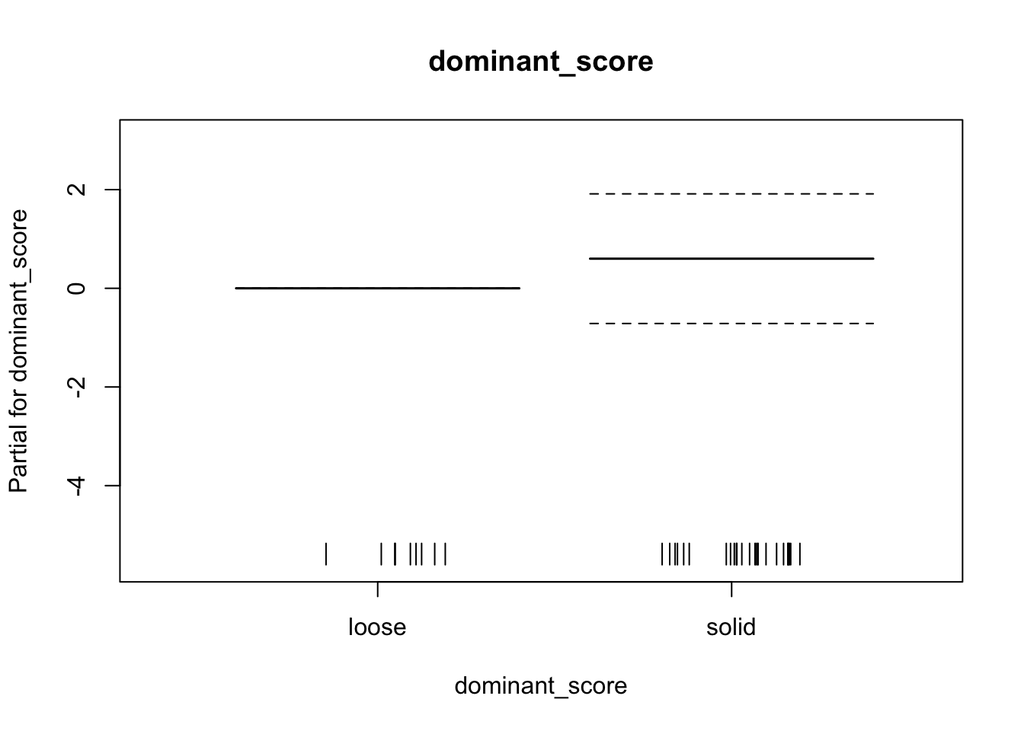

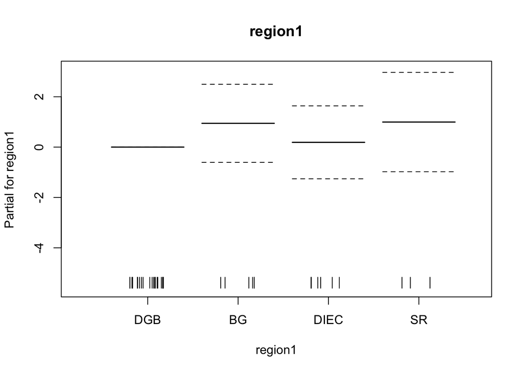

```
##
## Family: gaussian
## Link function: identity
##
## Formula:
## log(snail_dens + 0.01) ~ s(sst_scale) + norm_openness_scale +
##     dominant_score + region1
##
## Parametric coefficients:
##                     Estimate Std. Error t value Pr(>|t|)
## (Intercept)          -1.6676     0.5345  -3.120  0.00407 **
## norm_openness_scale  -1.0427     0.2952  -3.532  0.00140 **
## dominant_scoresolid   0.6004     0.6570   0.914  0.36830
## region1BG             0.9443     0.7754   1.218  0.23314
## region1DIEC           0.1896     0.7245   0.262  0.79543
## region1SR             0.9955     0.9864   1.009  0.32125
## ---
## Signif. codes:  0 '***' 0.001 '**' 0.01 '*' 0.05 '.' 0.1 ' ' 1
##
## Approximate significance of smooth terms:
##                    edf Ref.df F p-value
## s(sst_scale) 5.298e-05      9 0   0.796
##
## R-sq.(adj) =  0.323   Deviance explained = 42.3%
## -REML = 59.873  Scale est. = 2.3399    n = 35
```

Results showing the same trends with normalized openness included as a linear term. Region as a fixed effect does not seem to be significant.

##### Testing the residuals for autocorrelation

```
##
##  Moran I test under randomisation
##
## data:  residuals_ecology_snail_mod_linear_fe
## weights: lw
## n reduced by no-neighbour observations
##
## Moran I statistic standard deviate = 1.1804, p-value = 0.2379
## alternative hypothesis: two.sided
## sample estimates:
## Moran I statistic       Expectation          Variance
##        0.31856645       -0.05882353        0.10222393
```

```
##
##  Moran I test under randomisation
##
## data:  residuals_ecology_snail_mod_linear_fe
## weights: lw_inverse
##
## Moran I statistic standard deviate = 1.9699, p-value = 0.04886
## alternative hypothesis: two.sided
## sample estimates:
## Moran I statistic       Expectation          Variance
##        0.30457308       -0.02941176        0.02874662
```

Slight autocorrelation for inverse distance method

##### Testing the model for concurvity

```
## $worst
##                      para s(sst_scale)
## para         1.000000e+00 4.176841e-24
## s(sst_scale) 4.173844e-24 1.000000e+00
##
## $observed
##                      para s(sst_scale)
## para         1.000000e+00 2.753866e-31
## s(sst_scale) 4.173844e-24 1.000000e+00
##
## $estimate
##                      para s(sst_scale)
## para         1.000000e+00 9.168891e-28
## s(sst_scale) 4.173844e-24 1.000000e+00
```

```
##               para s(sst_scale)
## worst    0.9999917    0.9999999
## observed 0.9999917    0.7223694
## estimate 0.9999917    0.6835255
```

Temp and para are highly concurve.

#### Comparing Turban snail ecology models

```r
#To compare between the models we had fit to identify the best model we used
#AIC analysis. Specifically AIC corrected as our sample size was low.

#This runs the AIC on the different models
AICc(ecology_snail_mod_linear,
    ecology_snail_mod_linear_re,
    ecology_snail_mod_linear_fe)%>%
  #This arranges by the smallest AICc
  arrange(AICc)%>%
  #This makes a column of the delta AIC for ease of comparison
  mutate(delta_AICc = AICc - AICc[1])
```

```
##                                   df     AICc   delta_AICc
## ecology_snail_mod_linear    4.000095 134.2190 0.000000e+00
## ecology_snail_mod_linear_re 4.000132 134.2191 3.798235e-05
## ecology_snail_mod_linear_fe 7.000106 140.6456 6.426506e+00
```

AIC indicates that it does not improve the model by adding a random effect of region. The random effect is basically being removed from the model by the select = TRUE argument. This means that for the snail ecology model I will pick the more parsimonius model without the random effect.

Also, having region as a fixed effect makes the AIC much worse. Trying with both methods (REML and ML) the model with the fixed effect is much worse.

### Red sea urchin Ecology models

#### Model 5: Ecology model on the urchin counts with temperature, openness, and bottom type

```r
#For this model we tried with other distributions (tweedie, quasipoisson, scat)
#but the model fit appeared best with a simple gaussian model
ecology_urchin_mod <- gam(urchin_dens ~ s(sst_scale)+
                               s(norm_openness_scale)+
                           dominant_score,
                             data = env_mod_data_hon,
                             family = gaussian(link = "identity"),
                             method = "REML",
                             select = TRUE)
```

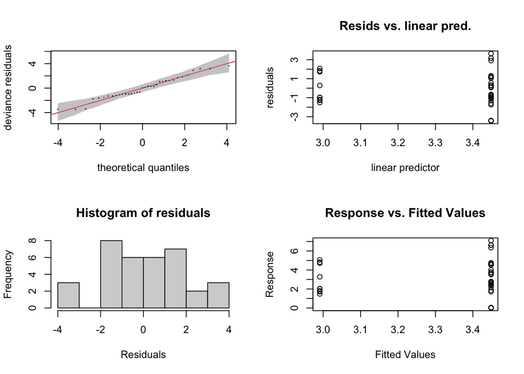

```
##
## Method: REML   Optimizer: outer newton
## full convergence after 12 iterations.
## Gradient range [-7.00498e-06,5.190015e-06]
## (score 70.05291 & scale 3.464059).
## Hessian positive definite, eigenvalue range [2.993136e-07,16.49999].
## Model rank =  20 / 20
##
## Basis dimension (k) checking results. Low p-value (k-index<1) may
## indicate that k is too low, especially if edf is close to k'.
##
##                              k'      edf k-index p-value
## s(sst_scale)           9.00e+00 1.73e-05    0.81    0.11
## s(norm_openness_scale) 9.00e+00 3.37e-05    0.70    0.01 **
## ---
## Signif. codes:  0 '***' 0.001 '**' 0.01 '*' 0.05 '.' 0.1 ' ' 1
```

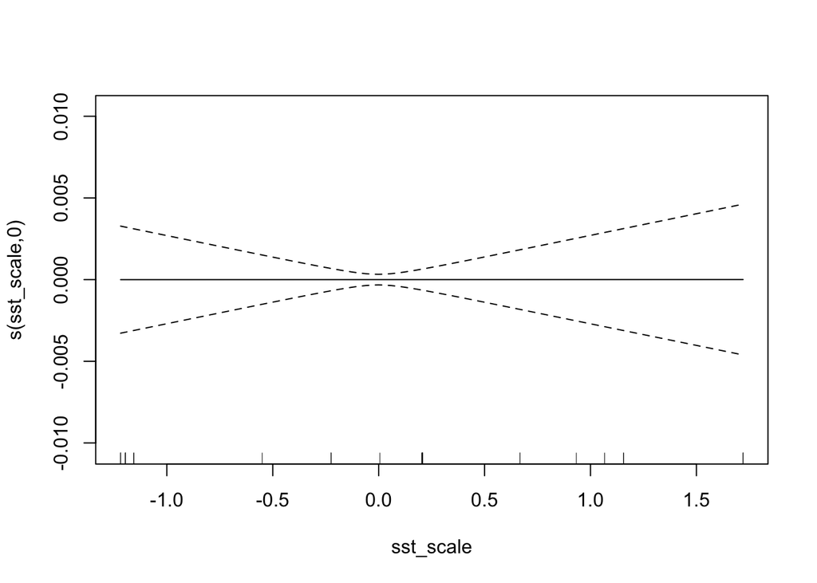

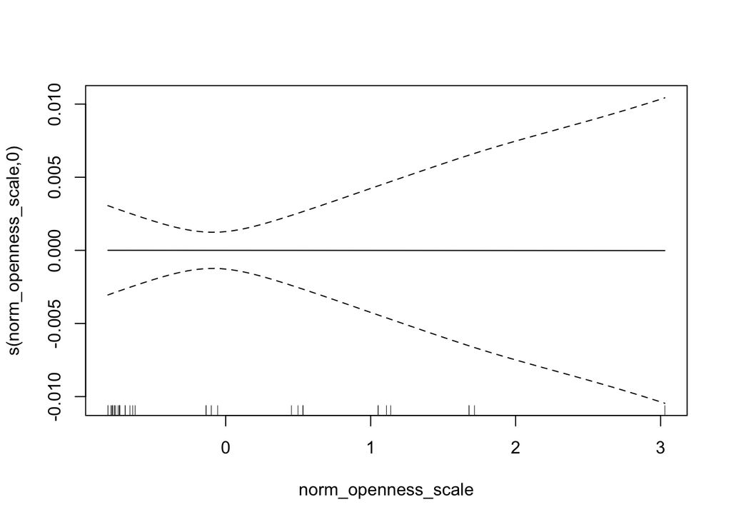

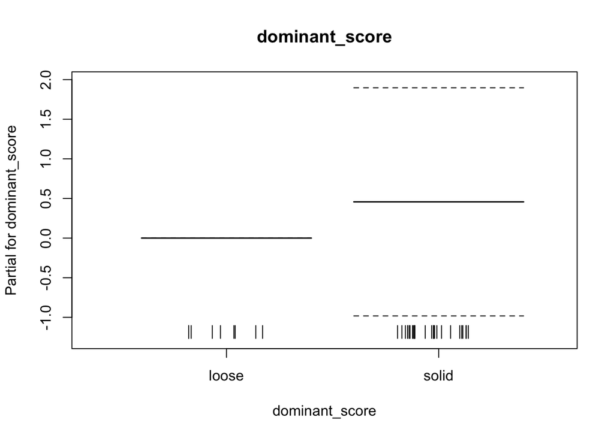

```
##
## Family: gaussian
## Link function: identity
##
## Formula:
## urchin_dens ~ s(sst_scale) + s(norm_openness_scale) + dominant_score
##
## Parametric coefficients:
##                     Estimate Std. Error t value Pr(>|t|)
## (Intercept)           2.9911     0.6204   4.821 3.12e-05 ***
## dominant_scoresolid   0.4574     0.7198   0.635     0.53
## ---
## Signif. codes:  0 '***' 0.001 '**' 0.01 '*' 0.05 '.' 0.1 ' ' 1
##
## Approximate significance of smooth terms:
##                              edf Ref.df F p-value
## s(sst_scale)           1.729e-05      9 0   0.707
## s(norm_openness_scale) 3.367e-05      9 0   0.724
##
## R-sq.(adj) =  -0.0179   Deviance explained = 1.21%
## -REML = 70.053  Scale est. = 3.4641    n = 35
```

```
##
##  Shapiro-Wilk normality test
##
## data:  ecology_urchin_mod$residuals
## W = 0.96335, p-value = 0.2874
```

##### Testing the residuals for autocorrelation

```
##
##  Moran I test under randomisation
##
## data:  residuals_ecology_urchin_mod
## weights: lw
## n reduced by no-neighbour observations
##
## Moran I statistic standard deviate = 1.3937, p-value = 0.1634
## alternative hypothesis: two.sided
## sample estimates:
## Moran I statistic       Expectation          Variance
##        0.39519494       -0.05882353        0.10612259
```

```
##
##  Moran I test under randomisation
##
## data:  residuals_ecology_urchin_mod
## weights: lw_inverse
##
## Moran I statistic standard deviate = 2.5621, p-value = 0.0104
## alternative hypothesis: two.sided
## sample estimates:
## Moran I statistic       Expectation          Variance
##        0.40854564       -0.02941176        0.02921947
```

Some positive autocorrelation but only with the inverse distance method. The neighbour method has no autocorrelation.

##### Testing the model for concurvity

```
## $worst
##                                para s(sst_scale) s(norm_openness_scale)
## para                   1.000000e+00 4.176841e-24           1.365142e-17
## s(sst_scale)           4.173961e-24 1.000000e+00           9.527043e-01
## s(norm_openness_scale) 1.365141e-17 9.527043e-01           1.000000e+00
##
## $observed
##                                para s(sst_scale) s(norm_openness_scale)
## para                   1.000000e+00 7.454951e-32           1.158196e-24
## s(sst_scale)           4.173961e-24 1.000000e+00           4.929191e-01
## s(norm_openness_scale) 1.365141e-17 4.803167e-01           1.000000e+00
##
## $estimate
##                                para s(sst_scale) s(norm_openness_scale)
## para                   1.000000e+00 9.168891e-28           2.363901e-21
## s(sst_scale)           4.173961e-24 1.000000e+00           4.716431e-01
## s(norm_openness_scale) 1.365141e-17 4.621752e-01           1.000000e+00
```

```
##              para s(sst_scale) s(norm_openness_scale)
## worst    0.864154    0.9530676              0.9529587
## observed 0.864154    0.5167011              0.5334175
## estimate 0.864154    0.4931624              0.5009083
```

Concurvity is high for temperature and openness. Both are being removed by the double penalty.

#### Model 6: Ecology model on the urchin counts with temperature, openness, and bottom type (random effect of region)

```r
#We wished to investigate using a random effect of region in the urchin model
#so we did that here
ecology_urchin_mod_re <- gam(urchin_dens ~ s(sst_scale)+
                               s(norm_openness_scale)+
                           dominant_score+
                                s(region1, bs = "re"),
                             data = env_mod_data_hon,
                             family = gaussian(link = "identity"),
                             method = "REML",
                             select = TRUE)
```

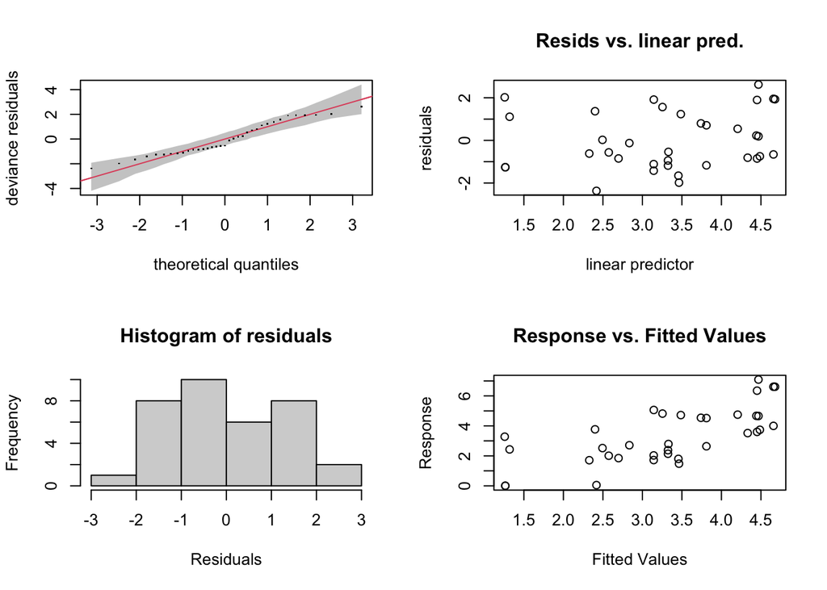

```
##
## Method: REML   Optimizer: outer newton
## full convergence after 11 iterations.
## Gradient range [-1.458549e-05,4.291018e-06]
## (score 66.57189 & scale 2.113725).
## Hessian positive definite, eigenvalue range [9.300168e-07,16.63197].
## Model rank =  24 / 24
##
## Basis dimension (k) checking results. Low p-value (k-index<1) may
## indicate that k is too low, especially if edf is close to k'.
##
##                           k'   edf k-index p-value
## s(sst_scale)           9.000 0.401    1.15    0.74
## s(norm_openness_scale) 9.000 1.211    1.00    0.43
## s(region1)             4.000 2.589      NA      NA
```

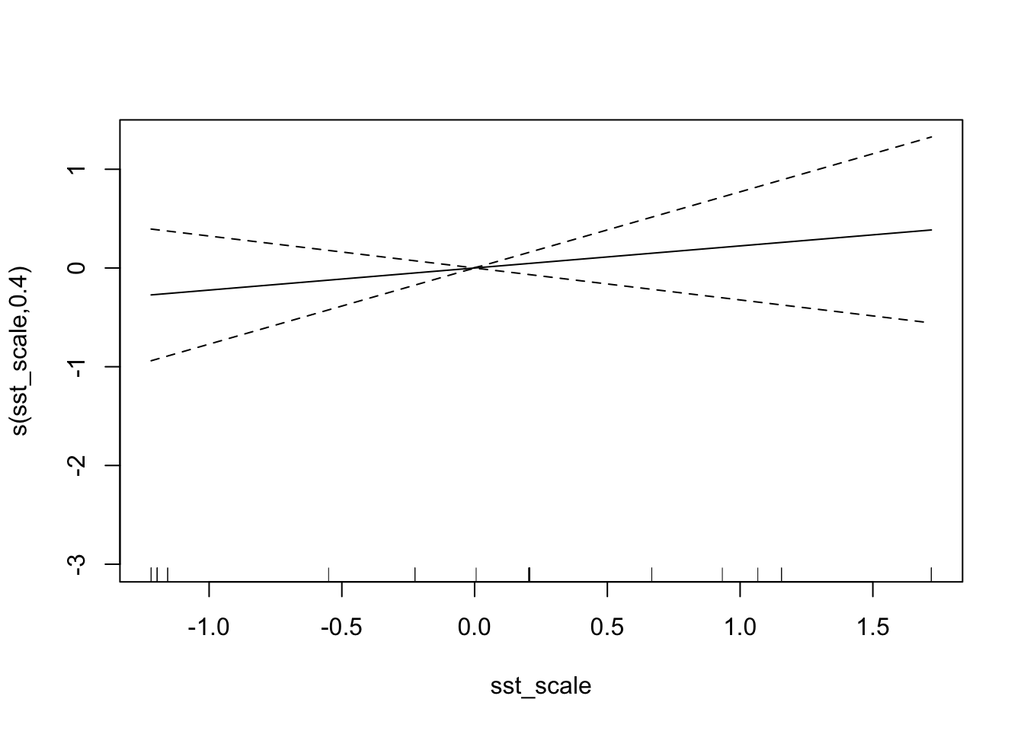

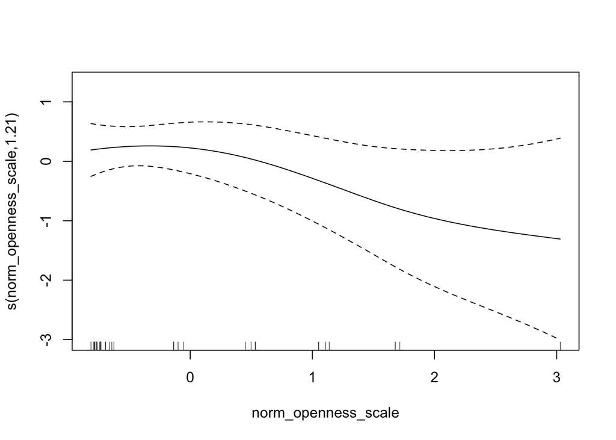

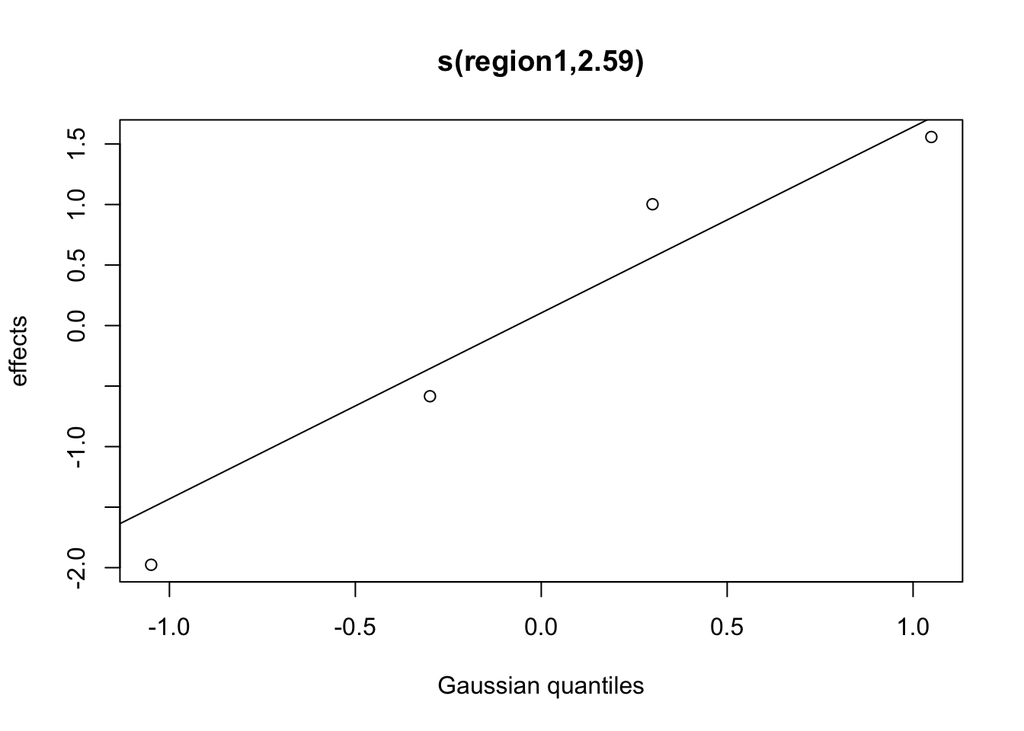

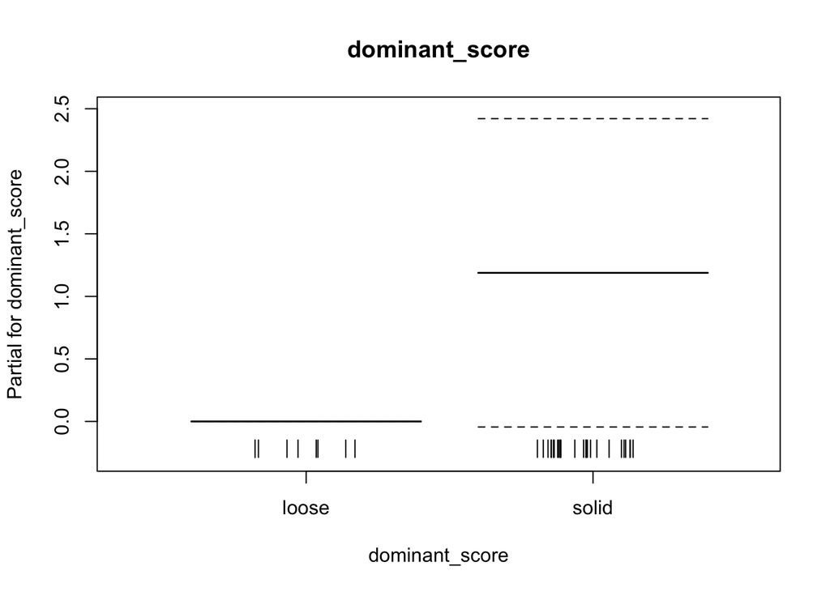

```
##
## Family: gaussian
## Link function: identity
##
## Formula:
## urchin_dens ~ s(sst_scale) + s(norm_openness_scale) + dominant_score +
##     s(region1, bs = "re")
##
## Parametric coefficients:
##                     Estimate Std. Error t value Pr(>|t|)
## (Intercept)           1.6556     1.0484   1.579   0.1252
## dominant_scoresolid   1.1883     0.6163   1.928   0.0638 .
## ---
## Signif. codes:  0 '***' 0.001 '**' 0.01 '*' 0.05 '.' 0.1 ' ' 1
##
## Approximate significance of smooth terms:
##                           edf Ref.df     F  p-value
## s(sst_scale)           0.4007      9 0.484 0.194823
## s(norm_openness_scale) 1.2111      9 0.645 0.085922 .
## s(region1)             2.5891      3 6.765 0.000282 ***
## ---
## Signif. codes:  0 '***' 0.001 '**' 0.01 '*' 0.05 '.' 0.1 ' ' 1
##
## R-sq.(adj) =  0.379   Deviance explained = 47.4%
## -REML = 66.572  Scale est. = 2.1137    n = 35
```

```
##
##  Shapiro-Wilk normality test
##
## data:  ecology_urchin_mod_re$residuals
## W = 0.94358, p-value = 0.07199
```

##### Testing the residuals for autocorrelation

```
##
##  Moran I test under randomisation
##
## data:  residuals_ecology_urchin_mod_re
## weights: lw
## n reduced by no-neighbour observations
##
## Moran I statistic standard deviate = 0.16269, p-value = 0.8708
## alternative hypothesis: two.sided
## sample estimates:
## Moran I statistic       Expectation          Variance
##      -0.004680189      -0.058823529       0.110760869
```

```
##
##  Moran I test under randomisation
##
## data:  residuals_ecology_urchin_mod_re
## weights: lw_inverse
##
## Moran I statistic standard deviate = -0.047373, p-value = 0.9622
## alternative hypothesis: two.sided
## sample estimates:
## Moran I statistic       Expectation          Variance
##       -0.03758723       -0.02941176        0.02978201
```

No autocorrelation for either method.

##### Testing the model for concurvity

```
## $worst
##                                para s(sst_scale) s(norm_openness_scale)
## para                   1.000000e+00 4.176841e-24           1.365142e-17
## s(sst_scale)           4.173961e-24 1.000000e+00           9.527043e-01
## s(norm_openness_scale) 1.365141e-17 9.527043e-01           1.000000e+00
## s(region1)             1.000000e+00 9.999999e-01           8.933562e-01
##                        s(region1)
## para                    1.0000000
## s(sst_scale)            0.9999999
## s(norm_openness_scale)  0.8933562
## s(region1)              1.0000000
##
## $observed
##                                para s(sst_scale) s(norm_openness_scale)
## para                   1.000000e+00 2.257383e-32           3.768417e-24
## s(sst_scale)           4.173961e-24 1.000000e+00           5.544408e-01
## s(norm_openness_scale) 1.365141e-17 4.832511e-01           1.000000e+00
## s(region1)             1.000000e+00 6.529173e-01           1.186232e-01
##                        s(region1)
## para                    0.3217451
## s(sst_scale)            0.6768189
## s(norm_openness_scale)  0.4895270
## s(region1)              1.0000000
##
## $estimate
##                                para s(sst_scale) s(norm_openness_scale)
## para                   1.000000e+00 9.168891e-28           2.363901e-21
## s(sst_scale)           4.173961e-24 1.000000e+00           4.716431e-01
## s(norm_openness_scale) 1.365141e-17 4.621752e-01           1.000000e+00
## s(region1)             1.000000e+00 6.222112e-01           9.130540e-02
##                        s(region1)
## para                    0.3926531
## s(sst_scale)            0.5771556
## s(norm_openness_scale)  0.2616596
## s(region1)              1.0000000
```

```
##          para s(sst_scale) s(norm_openness_scale) s(region1)
## worst       1    1.0000000              0.9885439  1.0000000
## observed    1    0.9069800              0.6465669  0.9991049
## estimate    1    0.8837833              0.6028679  0.9816727
```

Temp and region are basically fully concurve.

#### Model 7: Ecology model on the urchin counts with temperature, openness, and bottom type (fixed effect of region)

```r
#We also wanted to investigate the use of region as a fixed effect in the
#urchin model
ecology_urchin_mod_fe <- gam(urchin_dens ~ s(sst_scale)+
                               s(norm_openness_scale)+
                           dominant_score+
                                region1,
                             data = env_mod_data_hon,
                             family = gaussian(link = "identity"),
                             method = "REML",
                             select = TRUE)
```

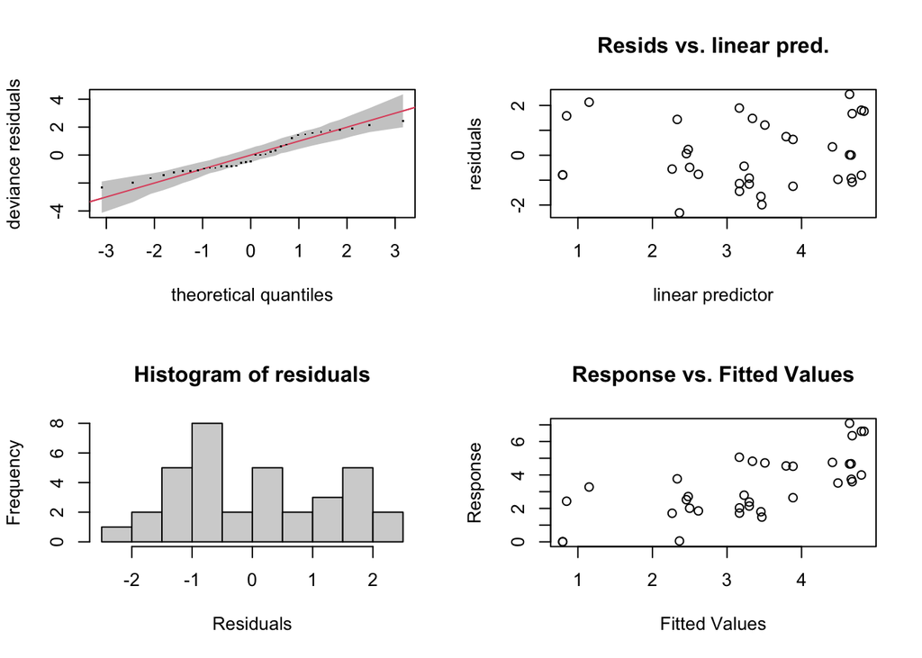

```
##
## Method: REML   Optimizer: outer newton
## full convergence after 11 iterations.
## Gradient range [-1.1223e-05,3.595235e-06]
## (score 59.70695 & scale 2.057157).
## Hessian positive definite, eigenvalue range [3.260958e-06,15.0378].
## Model rank =  23 / 23
##
## Basis dimension (k) checking results. Low p-value (k-index<1) may
## indicate that k is too low, especially if edf is close to k'.
##
##                           k'   edf k-index p-value
## s(sst_scale)           9.000 0.358    1.20    0.80
## s(norm_openness_scale) 9.000 1.445    1.04    0.49
```

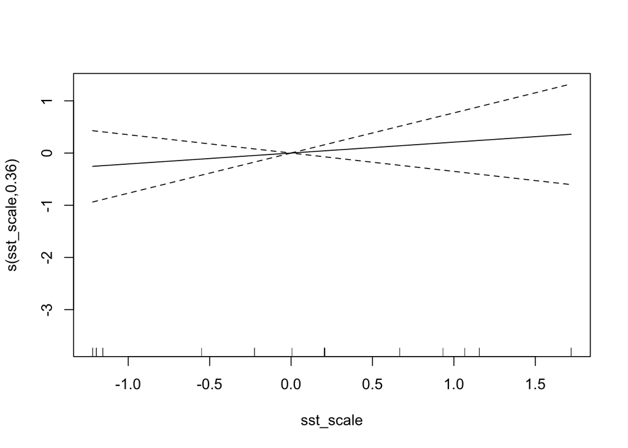

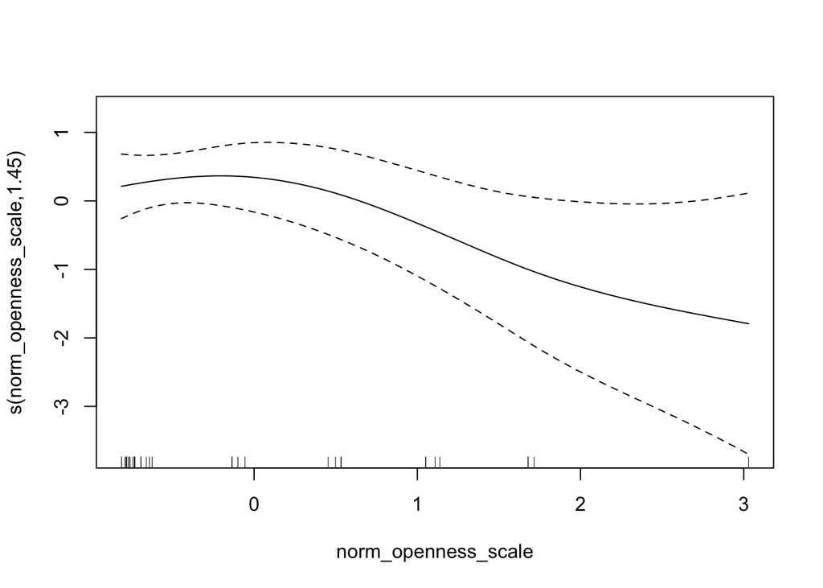

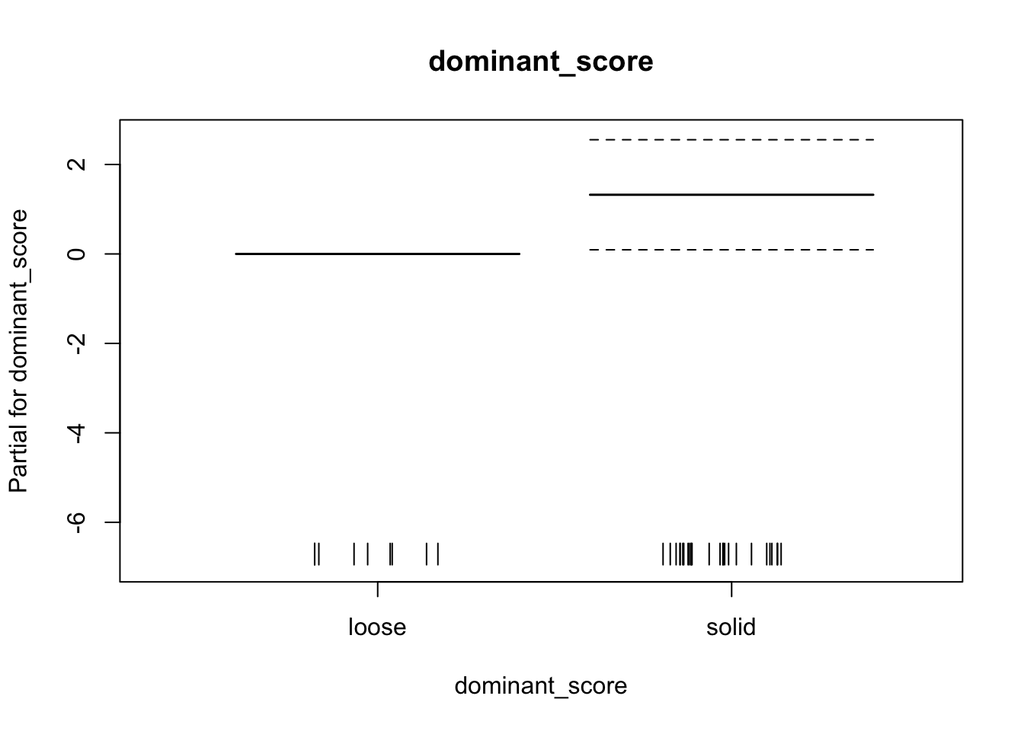

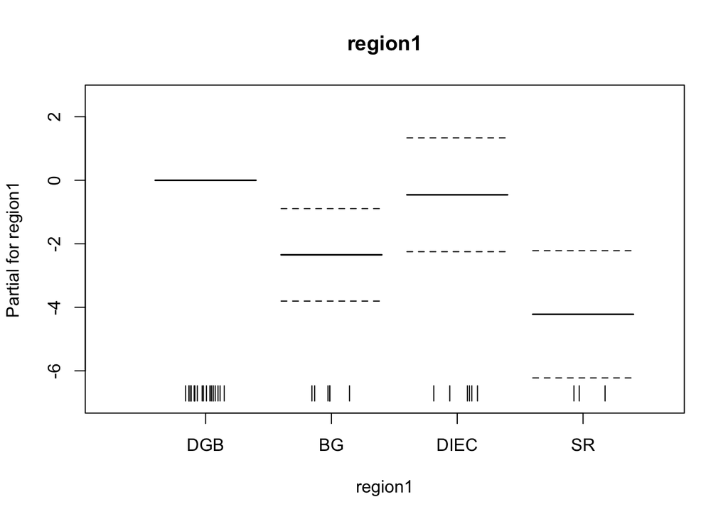

```
##
## Family: gaussian
## Link function: identity
##
## Formula:
## urchin_dens ~ s(sst_scale) + s(norm_openness_scale) + dominant_score +
##     region1
##
## Parametric coefficients:
##                     Estimate Std. Error t value Pr(>|t|)
## (Intercept)           3.1901     0.5349   5.964 1.96e-06 ***
## dominant_scoresolid   1.3231     0.6150   2.151 0.040158 *
## region1BG            -2.3467     0.7284  -3.222 0.003207 **
## region1DIEC          -0.4559     0.8960  -0.509 0.614865
## region1SR            -4.2196     1.0018  -4.212 0.000235 ***
## ---
## Signif. codes:  0 '***' 0.001 '**' 0.01 '*' 0.05 '.' 0.1 ' ' 1
##
## Approximate significance of smooth terms:
##                           edf Ref.df     F p-value
## s(sst_scale)           0.3576      8 0.070  0.2103
## s(norm_openness_scale) 1.4452      9 0.495  0.0522 .
## ---
## Signif. codes:  0 '***' 0.001 '**' 0.01 '*' 0.05 '.' 0.1 ' ' 1
##
## R-sq.(adj) =  0.396   Deviance explained = 49.9%
## -REML = 59.707  Scale est. = 2.0572    n = 35
```

```
##
##  Shapiro-Wilk normality test
##
## data:  ecology_urchin_mod_fe$residuals
## W = 0.94145, p-value = 0.06195
```

Gaussian looks ok. When adding the fixed effect of region the openness becomes borderline and negative. Also dominant substrate type becomes significant with more urchins on solid substrate.

##### Testing the residuals for autocorrelation

```
##
##  Moran I test under randomisation
##
## data:  residuals_ecology_urchin_mod_fe
## weights: lw
## n reduced by no-neighbour observations
##
## Moran I statistic standard deviate = -0.081806, p-value = 0.9348
## alternative hypothesis: two.sided
## sample estimates:
## Moran I statistic       Expectation          Variance
##       -0.08608200       -0.05882353        0.11102711
```

```
##
##  Moran I test under randomisation
##
## data:  residuals_ecology_urchin_mod_fe
## weights: lw_inverse
##
## Moran I statistic standard deviate = -0.51097, p-value = 0.6094
## alternative hypothesis: two.sided
## sample estimates:
## Moran I statistic       Expectation          Variance
##       -0.11764046       -0.02941176        0.02981430
```

No autocorrelation.

##### Testing the model for concurvity

```
## $worst
##                                para s(sst_scale) s(norm_openness_scale)
## para                   1.000000e+00 4.176841e-24           1.365142e-17
## s(sst_scale)           4.187013e-24 1.000000e+00           9.527043e-01
## s(norm_openness_scale) 1.365143e-17 9.527043e-01           1.000000e+00
##
## $observed
##                                para s(sst_scale) s(norm_openness_scale)
## para                   1.000000e+00 2.254736e-32           1.434475e-24
## s(sst_scale)           4.187013e-24 1.000000e+00           5.573310e-01
## s(norm_openness_scale) 1.365143e-17 4.832508e-01           1.000000e+00
##
## $estimate
##                                para s(sst_scale) s(norm_openness_scale)
## para                   1.000000e+00 9.168891e-28           2.363901e-21
## s(sst_scale)           4.187013e-24 1.000000e+00           4.716431e-01
## s(norm_openness_scale) 1.365143e-17 4.621752e-01           1.000000e+00
```

```
##              para s(sst_scale) s(norm_openness_scale)
## worst    0.999999    1.0000000              0.9882745
## observed 0.999999    0.8258532              0.6240525
## estimate 0.999999    0.8001208              0.5659471
```

Temp is very concurve.

##### Testing the model for VIF stuff

```r
#This performs a check of the collinearity of the variables in the model
performance::check_collinearity(ecology_urchin_mod_fe,
                   component = c("all"))
```

```
## # Check for Multicollinearity
##
## Low Correlation
##
##                    Term  VIF   VIF 95% CI Increased SE Tolerance
##            s(sst_scale) 1.45 [1.16, 2.27]         1.20      0.69
##  s(norm_openness_scale) 4.04 [2.72, 6.39]         2.01      0.25
##          dominant_score 1.23 [1.05, 2.09]         1.11      0.81
##                 region1 2.41 [1.73, 3.75]         1.55      0.41
##  Tolerance 95% CI
##      [0.44, 0.86]
##      [0.16, 0.37]
##      [0.48, 0.95]
##      [0.27, 0.58]
```

The resulting values indicate that there is acceptable correlation between the predictor variables.

#### Comparing the urchin ecology models

```r
AICc(ecology_urchin_mod,
     ecology_urchin_mod_re,
     ecology_urchin_mod_fe)%>%
  arrange(AICc)%>%
  mutate(delta_AICc = AICc - AICc[1])
```

```
##                             df     AICc delta_AICc
## ecology_urchin_mod_fe 8.470500 140.2331  0.0000000
## ecology_urchin_mod_re 8.163823 140.8152  0.5820727
## ecology_urchin_mod    3.000102 147.5261  7.2929691
```

When testing with REML, the model with the random effect is much better than the model with no random effect. When comparing with ML, the model with the fixed effect is much better than the model without the fixed effect. The model with the fixed and random effects are very similar in AIC and the random effect model has slightly lower df.

When repeating with urchin density and REML the fixed and random are basically the same.